# Visualisasi Data Tugas Pemro

Kelompok 1

2025-10-19

## Analisis Data Eksploratif (EDA)

### 1. Setup Awal

```r
# Memuat library yang diperlukan
library(knitr)
library(ggplot2)
library(tidyr)
library(readxl)
library(dplyr)
# 1. MEMUAT DATA
data_final <- read_excel("data_final_bersih.xlsx")
head(data_final)
```

```
## # A tibble: 6 × 7
##   `Satuan Wilayah Hukum` `Jumlah Kejahatan yang Dilaporkan` besaran_upah_minimum
##   <chr>                                               <dbl>                <dbl>
## 1 Polres Bogor                                         4030             4579541
## 2 Polres Ciamis                                        1077             2089464
## 3 Polres Cianjur                                       1951             2915102
## 4 Polres Cimahi                                        2402             3568278.
## 5 Polres Kota Cirebon                                   938             2533038
## 6 Polres Garut                                         1526             2186437
## # ℹ 4 more variables: kepadatan_penduduk <dbl>,
## #   `Produk Domestik Regional Bruto per Kapita Atas Dasar Harga Berlaku (Ribu Rp)` <dbl>,
## #   tingkat_pengangguran_terbuka <dbl>, putus_sekolah <dbl>
```

### 2. Analisis Data Eksploratif (EDA)

#### Statistik Deskriptif

Pertama, akan melihat ringkasan statistik dasar untuk semua variabel. Fungsi summary() akan memberi kita Min (Minimum), Median, Mean (Rata-rata), dan Max (Maksimum). Untuk Varians, kita perlu menghitungnya secara terpisah.

```r
# 2. Statistik deskriptif dasar (Min, Median, Mean, Max, Kuartil)
summary(data_final)
```

```
##  Satuan Wilayah Hukum Jumlah Kejahatan yang Dilaporkan besaran_upah_minimum
##  Length:23            Min.   : 203.0                   Min.   :2070192
##  Class :character     1st Qu.: 892.5                   1st Qu.:2387800
##  Mode  :character     Median :1463.0                   Median :2834399
##                       Mean   :1602.6                   Mean   :3130211
##                       3rd Qu.:2076.5                   3rd Qu.:3548123
##                       Max.   :4036.0                   Max.   :5257834
##  kepadatan_penduduk
##  Min.   :  1.030
##  1st Qu.:  2.074
##  Median :  9.036
##  Mean   :298.343
##  3rd Qu.:732.500
##  Max.   :954.000
##  Produk Domestik Regional Bruto per Kapita Atas Dasar Harga Berlaku (Ribu Rp)
##  Min.   : 24914
##  1st Qu.: 30220
##  Median : 39445
##  Mean   : 50447
##  3rd Qu.: 55012
##  Max.   :147081
##  tingkat_pengangguran_terbuka putus_sekolah
##  Min.   :1.580                Min.   : 0.00
##  1st Qu.:6.075                1st Qu.: 1.00
##  Median :6.730                Median : 5.00
##  Mean   :6.323                Mean   :10.93
##  3rd Qu.:7.370                3rd Qu.:16.25
##  Max.   :8.340                Max.   :74.00
```

```r
# 3. Menghitung Varians
varians_data <- data_final %>%
  select(where(is.numeric)) %>%  # Memilih hanya kolom numerik
  summarise(across(everything(), ~ var(.x, na.rm = TRUE))) %>%
  # Merapikan tabel untuk dibaca
  pivot_longer(everything(), names_to = "Variabel", values_to = "Varians")
kable(varians_data, caption = "Varians untuk Setiap Variabel Numerik")
```

Varians untuk Setiap Variabel Numerik

| Variabel | Varians |
| --- | --- |
| Jumlah Kejahatan yang Dilaporkan | 1.073734e+06 |
| besaran_upah_minimum | 9.487469e+11 |
| kepadatan_penduduk | 1.495137e+05 |
| Produk Domestik Regional Bruto per Kapita Atas Dasar Harga Berlaku (Ribu Rp) | 9.991873e+08 |
| tingkat_pengangguran_terbuka | 2.885216e+00 |
| putus_sekolah | 2.699160e+02 |

#### Visualisasi Data (ggplot2)

##### Histogram Variabel Respon (Jumlah Kejahatan)

Histogram dibuat untuk melihat distribusi dari variabel respon, yaitu Jumlah Kejahatan yang Dilaporkan. Ini membantu kita melihat apakah datanya skewed (miring) atau tidak.

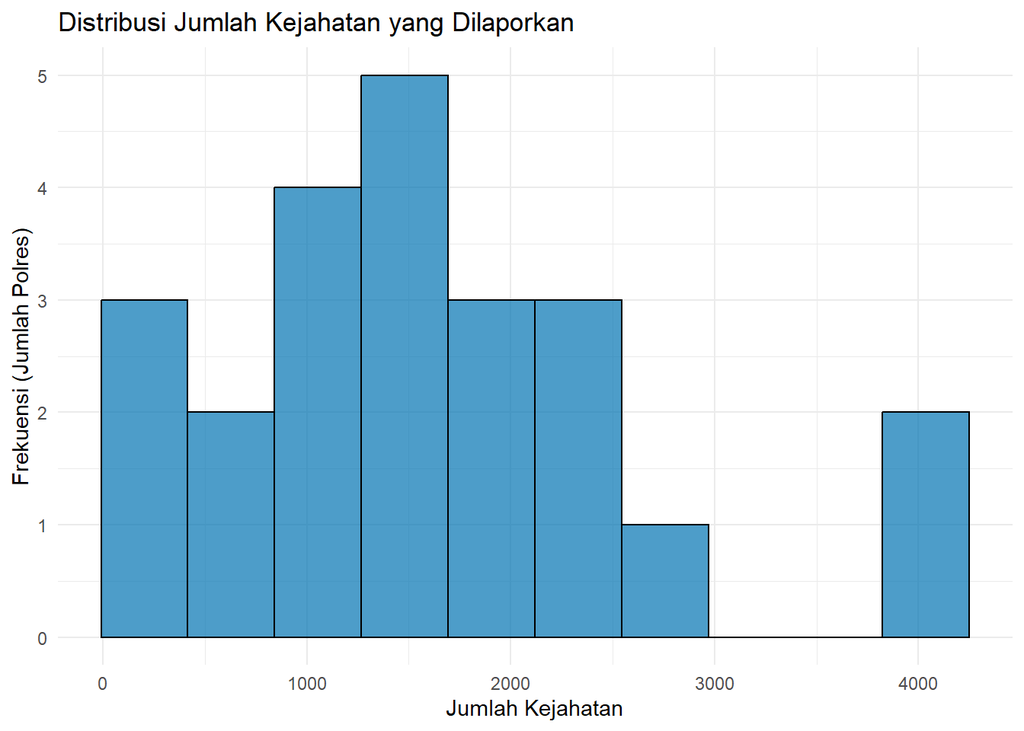

```r
# Membuat histogram untuk 'Jumlah Kejahatan yang Dilaporkan'
ggplot(data_final, aes(x = `Jumlah Kejahatan yang Dilaporkan`)) +
  geom_histogram(bins = 10, fill = "#0072B2", color = "black", alpha = 0.7) +
  labs(
    title = "Distribusi Jumlah Kejahatan yang Dilaporkan",
    x = "Jumlah Kejahatan",
    y = "Frekuensi (Jumlah Polres)"
  ) +
  theme_minimal()
```

Penjelasan: Dari histogram ini, kita bisa melihat bahwa sebagian besar Polres memiliki jumlah kejahatan di angka yang rendah, namun ada beberapa Polres dengan jumlah kejahatan yang sangat tinggi (ekor di sebelah kanan). Ini disebut right-skewed.

##### Boxplot Distribusi Variabel

Boxplot berguna untuk melihat rentang data (dari min ke max), interquartile range (IQR), median, dan mendeteksi outlier. Scaling (standardisasi) perlu dilakukan terlebih dahulu untuk membandingkan distribusi semua variabel, karena satuannya berbeda-beda (misal Upah dalam jutaan, Pengangguran hanya satuan).

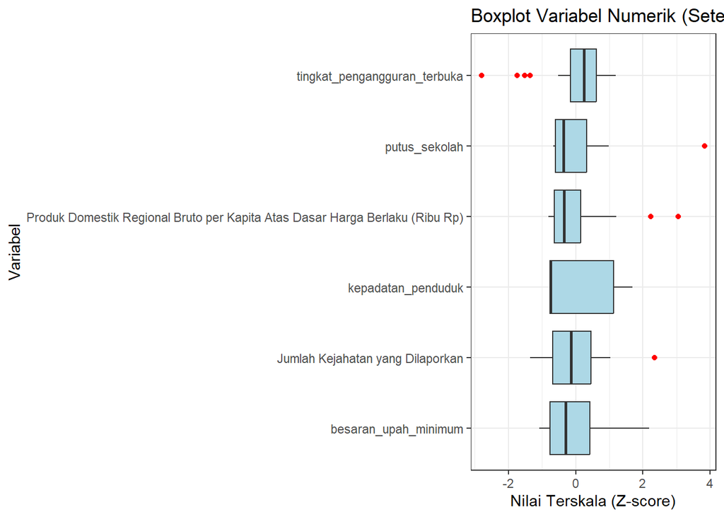

```r
# 1. Menyiapkan data: Pilih numerik -> scaling -> ubah ke format 'long'
data_scaled_long <- data_final %>%
  select(where(is.numeric)) %>%
  scale() %>% # Scaling data (Z-score)
  as.data.frame() %>%
  pivot_longer(everything(), names_to = "Variabel", values_to = "Nilai_Terskala")

# 2. Membuat boxplot
ggplot(data_scaled_long, aes(x = Variabel, y = Nilai_Terskala)) +
  geom_boxplot(fill = "lightblue", outlier.color = "red") +
  coord_flip() + # Memutar plot agar label variabel mudah dibaca
  labs(
    title = "Boxplot Variabel Numerik (Setelah Scaling)",
    x = "Variabel",
    y = "Nilai Terskala (Z-score)"
  ) +
  theme_bw()
```

##### Scatter Plot (Hubungan Antar Variabel)

Terakhir, scatter plot dibuat untuk melihat hubungan antara variabel predictor (sosial ekonomi) dengan variabel response (Jumlah Kejahatan). Agar efisien, kita akan menggunakan pivot_longer() untuk merapikan data, lalu facet_wrap() untuk membuat semua plot dalam satu gambar.

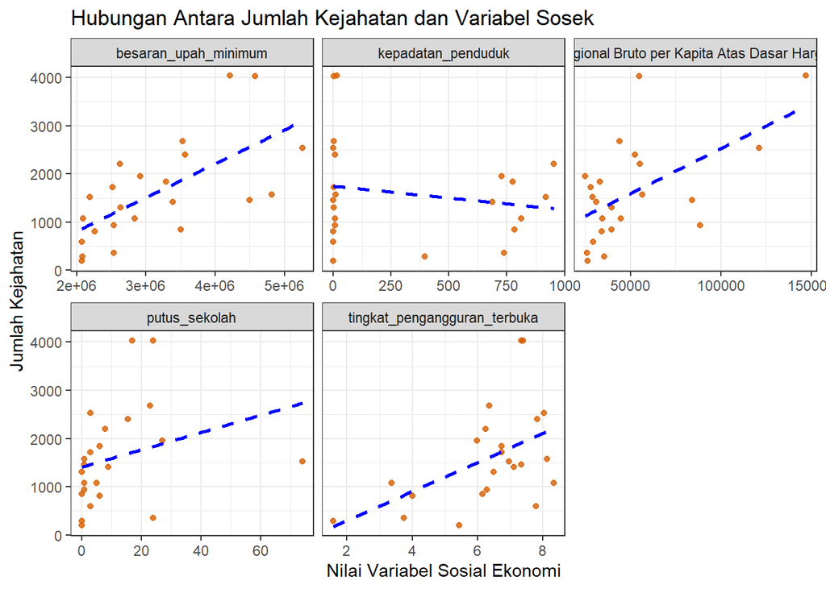

```r
# 1. Ubah data ke format 'long'
# Kita pisahkan variabel Sosial ekonomi (prediktor) dan Kejahatan (respon)
data_plot_long <- data_final %>%
  pivot_longer(
    cols = -c(`Satuan Wilayah Hukum`, `Jumlah Kejahatan yang Dilaporkan`),
    names_to = "Variabel_Sosek",
    values_to = "Nilai"
  )

# 2. Membuat scatter plot dengan facet_wrap
ggplot(data_plot_long, aes(x = Nilai, y = `Jumlah Kejahatan yang Dilaporkan`)) +
  geom_point(color = "#D55E00", alpha = 0.8) +
  geom_smooth(method = "lm", se = FALSE, color = "blue", linetype = "dashed") +
  # facet_wrap sangat penting di sini
  # scales = "free_x" mengizinkan sumbu X memiliki skala berbeda-beda
  facet_wrap(~ Variabel_Sosek, scales = "free_x", ncol = 3) +
  labs(
    title = "Hubungan Antara Jumlah Kejahatan dan Variabel Sosek",
    x = "Nilai Variabel Sosial Ekonomi",
    y = "Jumlah Kejahatan"
  ) +
  theme_bw()
```

Penjelasan : Grafik: Setiap kotak adalah scatter plot antara satu variabel sosek (sumbu X) dan Jumlah Kejahatan (sumbu Y). Garis Biru: Ini adalah garis regresi linear.